# Functions for Visualizing Data

Jacob Hamel-Mottiez

2025-01-21

```r
# PACKAGES ----------------------------------------------------------------
library(tidyverse)
```

```r
library(janitor)
library(ggplot2)
library(plotly)
library(highcharter)
library(knitr)
library(patchwork)
library(purrr)
```

# 1 What is The Goal of This file?

The main goal of this file is to create functions that will ease data visualization for my master project. In this notebook, you will find various functions :

- **temporal_distrib_papers()** : this function plot the number of papers published since the creation of a journal. With this function you get the data points as well as a smoothed curve for it.
- **philo_bio_in_general_all()** : this function plot all of the articles published by a journal (in our case a general philosophy of science journal) and distinguishes references to philosophy of biology journals from other references.
- **philo_bio_in_general_year()** : this function groups articles by their year of publication and finds the mean of the references to philosophy of biology and the mean from the rest of the references.

# 2 Temporal Distribution of The Papers

The goal of this function is to plot the articles from different journals (e.g. *Biology and Philosophy*, *Biological Theory*, etc.), in a fashion that makes it possible to see the number of articles published since the journal creation. Importantly, this function filter out editorials as well as reviews to keep only articles. Here is an example of this function with the journal *Biology and Philosophy* ranging from 1986-2024.

```r
bio_philo_papers <- read_csv(paste0(dir_od, "bio_philo_papers.csv"))
```

## 2.1 temporal_distrib_papers()

```r
temporal_distrib_papers <- function(data, color){
# Preprocess data
  data$prism_cover_date <- format(data$prism_cover_date, format = "%Y") |> as.numeric()
  data_filtered <- data |> select(prism_publication_name, prism_cover_date, subtype_description) |>
    filter(subtype_description == "Article")

  data_filtered <- data_filtered  |> count(prism_cover_date, sort = TRUE)


# Visualisation
  g <- ggplot(data_filtered, aes(x = prism_cover_date, y = n)) +
    geom_point() +
    geom_smooth(method = "loess",  # Loess smoothing
                fill = "gray", alpha = 0.5, se = TRUE, color = color) +
    labs(title = "temporal_distrib_papers()",
         x = "Year",
         y = "No. of Papers") +
    theme(
      plot.title = element_text(hjust = 0.5, face = "bold"),   # Bold, centered title
      axis.text.x = element_text(size=14, face = "bold"),              # Bold x-axis text
      axis.text.y = element_text(size=14, face = "bold"),               # Bold y-axis text
      axis.title.x = element_text(size=14, face="bold"),
      axis.title.y = element_text(size=14, face="bold"),
    )
  return(g)
}
```

```r
dir_papers <- "C:/Users/jacob/OneDrive - Université Laval/biophilo/Data/Philosophy of Biology/"

# BIOLOGY AND/& PHILOSOPHY
bio_philo1_papers <- read_csv(paste0(dir_papers, "BIOLOGY_AND_PHILOSOPHY_papers_2025-01-20.csv"))
bio_philo2_papers <- read_csv(paste0(dir_papers, "BIOLOGY_&_PHILOSOPHY_papers_2025-01-20.csv"))
bio_philo1_papers <- bio_philo1_papers[, colnames(bio_philo1_papers) %in% colnames(bio_philo2_papers)]
bio_philo_papers_all <- rbind(bio_philo1_papers, bio_philo2_papers)

# BIOLOGICAL THEORY
bio_theory_papers <- read_csv(paste0(dir_papers, "BIOLOGICAL_THEORY_papers_2025-01-20.csv"))
HPLS_papers <- read_csv(paste0(dir_papers, "HISTORY_AND_PHILOSOPHY_OF_THE_LIFE_SCIENCES_papers_2025-01-20.csv"))
BJPS_papers <- read_csv(paste0(dir_papers, "British_Journal_for_the_Philosophy_of_Science_papers_2025-01-20.csv"))

all_journals <- c("bio_philo_papers_all", "bio_theory_papers", "HPLS_papers", "BJPS_papers")
```

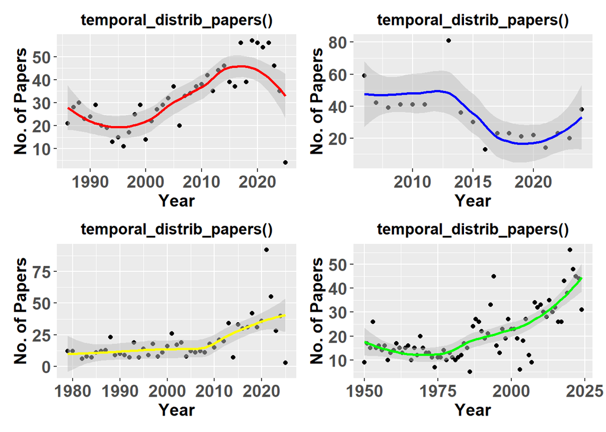

```r
p1 <- temporal_distrib_papers(bio_philo_papers_all, color = "red")
p2 <- temporal_distrib_papers(bio_theory_papers, "blue")
p3 <- temporal_distrib_papers(HPLS_papers, "yellow")
p4 <- temporal_distrib_papers(BJPS_papers, "green")

p1+p2+p3+p4
```

# 3 Philosophy of Biology Articles Hidden in General Philosophy of Science Journals

The goal of this function is to represent the amount of references in each articles of general philosophy that are from one of our corpus of philosophy of biology. The idea is that some of the articles published in general philosophy of biology journals are in fact talking about philosophy of biology issue. Hence, with the appropriate threshold, we can infer after a given number of citation to philosophy of biology works that the article initially published in general philosophy of science is in fact about philosophy of biology (for more information, see : `C:/Users/jacob/OneDrive - Université Laval/biophilo/filtering_biophilo_in_general_2025-01-16.R`)

First, we need to identify which journals are journals of philosophy of biology. Here is an example of some of them for the purpose of the present showcase :

```r
philo_bio_journals <- c("BIOLOGY & PHILOSOPHY",
                        "BIOLOGY AND PHILOSOPHY",
                        "BIOLOGICAL THEORY",
                        "PHILOSOPHICAL TRANSACTIONS OF THE ROYAL SOCIETY B: BIOLOGICAL SCIENCES",
                        "STUDIES IN HISTORY AND PHILOSOPHY OF SCIENCE PART C :STUDIES IN HISTORY AND PHILOSOPHY OF BIOLOGICAL AND BIOMEDICAL SCIENCES",
                        "HISTORY AND PHILOSOPHY OF THE LIFE SCIENCES")

kable(philo_bio_journals,col.names = "Journals Of Philosophy of Biology", format = )
```

| Journals Of Philosophy of Biology |
| --- |
| BIOLOGY & PHILOSOPHY |
| BIOLOGY AND PHILOSOPHY |
| BIOLOGICAL THEORY |
| PHILOSOPHICAL TRANSACTIONS OF THE ROYAL SOCIETY B: BIOLOGICAL SCIENCES |
| STUDIES IN HISTORY AND PHILOSOPHY OF SCIENCE PART C :STUDIES IN HISTORY AND PHILOSOPHY OF BIOLOGICAL AND BIOMEDICAL SCIENCES |
| HISTORY AND PHILOSOPHY OF THE LIFE SCIENCES |

With this information, we can now count how many references are from those journals in a specific generalist philosophy of science journal (here the British Journal for Philosophy of Science or BJPS).

```r
BJPS_references <- read_csv(paste0(dir_od, "BJPS_query_references_2025-01-16.csv")) |> clean_names()
BJPS_articles <- read_csv(paste0(dir_od, "BJPS_query_papers_2025-01-16.csv")) |> clean_names()
```

## 3.1 philo_bio_in_general_all()

```r
philo_bio_in_general_all <- function(references, articles, philo_bio_journals){
  ## Preprocessing
  references$sourcetitle <- toupper(references$sourcetitle)

  reference_is_article <- left_join(references, articles |> select(dc_identifier, subtype_description),
                                    by = join_by(citing_art == dc_identifier)) |>
    filter(subtype_description == "Article")



  reference_is_article <- reference_is_article |> mutate(is_philo_bio = ifelse(sourcetitle %in% philo_bio_journals, TRUE, FALSE))
  reference_is_article <-  reference_is_article |>
    mutate(is_philo_bio_journal = if_else(sourcetitle %in% philo_bio_journals, TRUE, FALSE)) |>
    group_by(citing_art) |>
    mutate(n_ref_bio_philo = sum(is_philo_bio_journal, na.rm = TRUE)) |>
    ungroup()


  reference_is_article <- reference_is_article |> select(citing_art, scopus_eid, sourcetitle, is_philo_bio, n_ref_bio_philo)|>
    filter(!is.na(scopus_eid)) |>
    add_count(citing_art, name = "n_ref")


  ## Visualization -----------------------------------------------------------
  articles_only <- reference_is_article |> select(-scopus_eid, -sourcetitle, -is_philo_bio) |> distinct()
  data_long <- articles_only |> pivot_longer(cols = c(n_ref, n_ref_bio_philo),
                                             names_to = "category",
                                             values_to = "count") |> distinct()


  g <- ggplot(data_long, aes(x = citing_art, y = count, fill = category)) +
    geom_bar(stat = "identity", position = "stack") +
    theme_minimal() +
    labs(title = "philo_bio_in_general_all()",
         x = "Citing Article",
         y = "No. of References",
         fill = "Category")  +
    theme(
      plot.title = element_text(hjust = 0.5, face = "bold"),   # Bold, centered title
      axis.text.x = element_blank(),              # Bold x-axis text
      axis.text.y = element_text(size=14, face = "bold"),               # Bold y-axis text
      axis.title.x = element_text(size=14, face="bold"),
      axis.title.y = element_text(size=14, face="bold"))
  show(g)

}
```

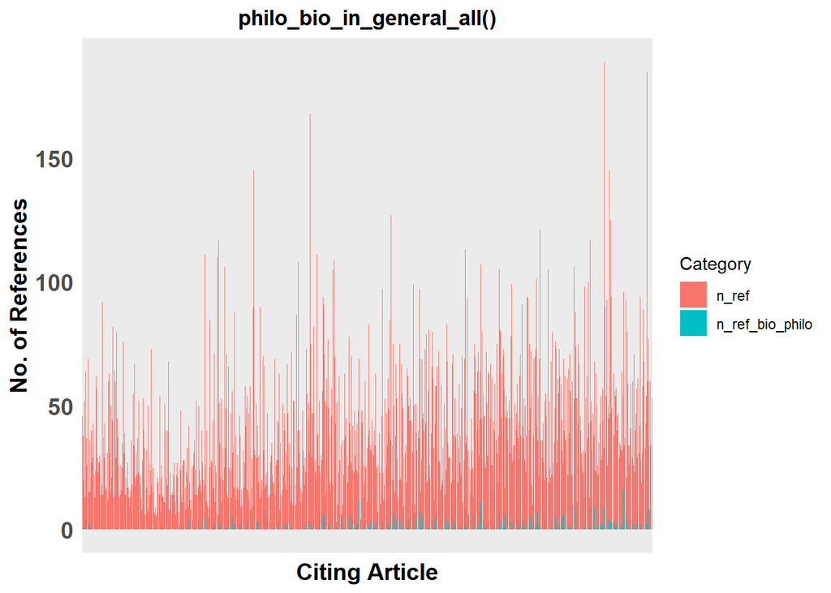

```r
philo_bio_in_general_all(BJPS_references, BJPS_articles, philo_bio_journals)
```

Obviously, ploting all those article on the x-axis is a bit overwhelming. The next function aims at answering this limitation. More precisly, we group articles by their year, and take the mean of their total refs and the refs going to philosophy of biology.

## 3.2 philo_bio_in_general_year()

```r
philo_bio_in_general_year <- function(articles, references) {

  ## Process references data
  references$sourcetitle <- toupper(references$sourcetitle)
  reference_is_article <- left_join(articles |> select(dc_identifier, subtype_description), references,
                                    by = join_by(dc_identifier == citing_art)) |>
    filter(subtype_description == "Article")

  reference_is_article <- reference_is_article |> rename(citing_art = dc_identifier)


  reference_is_article <-  reference_is_article |>
    mutate(is_philo_bio_journal = if_else(sourcetitle %in% philo_bio_journals, TRUE, FALSE)) |>
    group_by(citing_art) |>
    mutate(n_ref_bio_philo = sum(is_philo_bio_journal, na.rm = TRUE)) |>
    ungroup()

  reference_is_article <- reference_is_article |> select(citing_art, scopus_eid, sourcetitle, is_philo_bio_journal, n_ref_bio_philo)|>
    filter(!is.na(scopus_eid)) |>
    add_count(citing_art, name = "n_ref")

  philo_bio_articles_in_general <- reference_is_article |> select(-scopus_eid, -sourcetitle, -is_philo_bio_journal) |>
    distinct()


  ## Mean by year
  philo_bio_articles_in_general <- left_join(articles |> select(dc_identifier, prism_cover_date), philo_bio_articles_in_general, by = join_by(dc_identifier == citing_art))


  philo_bio_articles_in_general$prism_cover_date <- format(philo_bio_articles_in_general$prism_cover_date, format = "%Y") |> as.numeric()
  print(philo_bio_articles_in_general |> filter(prism_cover_date == 1986))

  philo_bio_articles_in_general <- philo_bio_articles_in_general %>%
    group_by(prism_cover_date) %>%
    mutate(
      mean_n_ref = mean(n_ref, na.rm = TRUE),
      mean_n_ref_bio_philo = mean(n_ref_bio_philo, na.rm = TRUE)) %>%
    ungroup()

philo_bio_articles_in_general <- philo_bio_articles_in_general |> select(prism_cover_date, mean_n_ref,  mean_n_ref_bio_philo)





  data_long <- philo_bio_articles_in_general |> pivot_longer(cols = c(mean_n_ref, mean_n_ref_bio_philo),
                                             names_to = "category",
                                             values_to = "count") |> distinct()

  g <- ggplot(data_long, aes(x = prism_cover_date, y = count, fill = category)) +
    geom_bar(stat = "identity", position = "stack") +
    labs(
      title = "philo_bio_in_general_year()",
      x = "Year",
      y = "Mean N. of References",
      fill = NULL) +
    theme(
      plot.title = element_text(hjust = 0.5, face = "bold"),   # Bold, centered title
      axis.text.x = element_text(size=14, face = "bold"),              # Bold x-axis text
      axis.text.y = element_text(size=14, face = "bold"),               # Bold y-axis text
      axis.title.x = element_text(size=14, face="bold"),
      axis.title.y = element_text(size=14, face="bold"),
      )
  show(g)

}
```

```r
philo_bio_in_general_year(BJPS_articles, BJPS_references)
```

```
## # A tibble: 27 × 4
##    dc_identifier         prism_cover_date n_ref_bio_philo n_ref
##    <chr>                            <dbl>           <int> <int>
##  1 SCOPUS_ID:84963012050             1986              NA    NA
##  2 SCOPUS_ID:84962984028             1986               0     7
##  3 SCOPUS_ID:84960609940             1986              NA    NA
##  4 SCOPUS_ID:84960598291             1986              NA    NA
##  5 SCOPUS_ID:84960598117             1986              NA    NA
##  6 SCOPUS_ID:84960567721             1986              NA    NA
##  7 SCOPUS_ID:84960567583             1986              NA    NA
##  8 SCOPUS_ID:84960560267             1986               0    10
##  9 SCOPUS_ID:84954754089             1986              NA    NA
## 10 SCOPUS_ID:84950455745             1986              NA    NA
## # ℹ 17 more rows
```

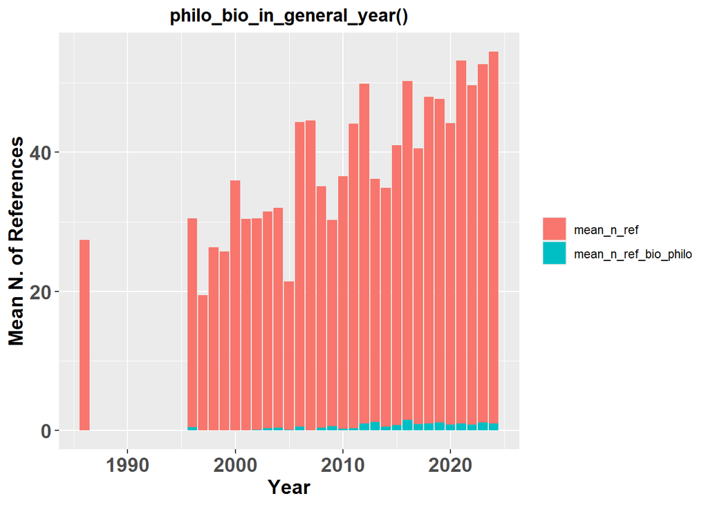

In this case, we see that there is a weird gap between 1986 and 1996. It shows that if the functions are useful, a clean data set is essential for optimal visualisation. Hence, with the cleaned data :

```r
BJPS_articles <- BJPS_articles |> filter(format(BJPS_articles$prism_cover_date, format = "%Y") |> as.numeric() != 1986)
philo_bio_in_general_year(BJPS_articles, BJPS_references)
```

```
## # A tibble: 0 × 4
## # ℹ 4 variables: dc_identifier <chr>, prism_cover_date <dbl>,
## #   n_ref_bio_philo <int>, n_ref <int>
```

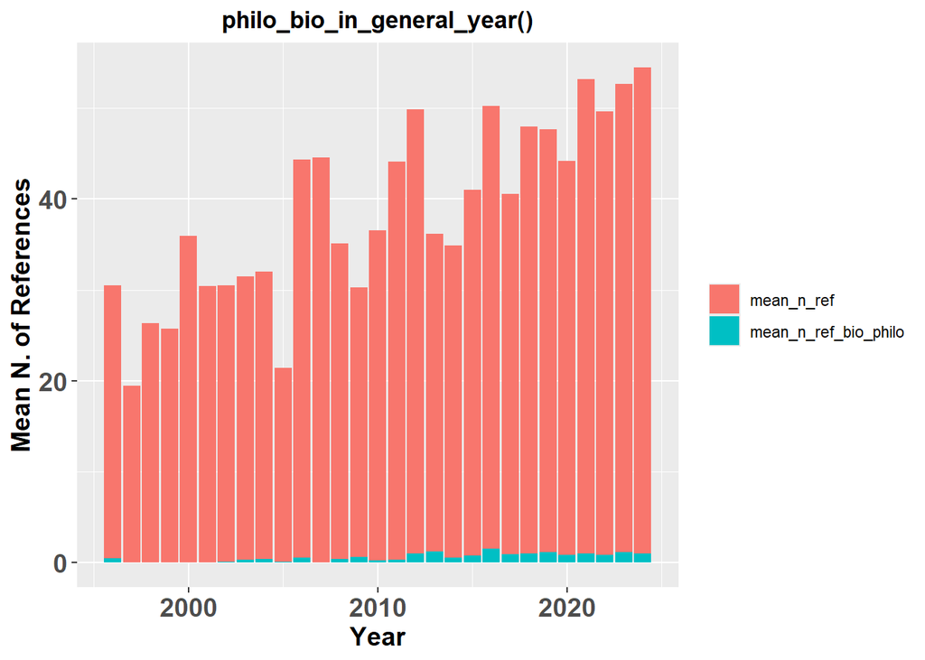

In this case, we see that for the articles in our dataset (here for showcase we went with BJPS), the number of references by paper that are not in our philosophy of biology dataset is increasing through time, where the references that are in our philosophy of biology dataset are somewhat constant after 2010.